# subsidyexploration

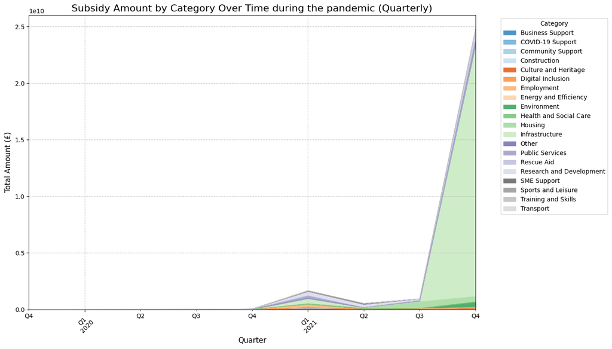

```python
plt.figure(figsize=(14, 8))

category_pivot.plot(
    kind='area',
    stacked=True,
    figsize=(14, 8),
    colormap='tab20c',
    alpha=0.85,
    linewidth=0.5
)

plt.title('Subsidy Amount by Category Over Time during the pandemic (Quarterly)', fontsize=16)
plt.xlabel('Quarter', fontsize=12)
plt.ylabel('Total Amount (£)', fontsize=12)
plt.xticks(rotation=45)
plt.grid(True, linestyle='--', alpha=0.7)
plt.legend(title='Category', bbox_to_anchor=(1.05, 1), loc='upper left')
plt.tight_layout()
plt.show()
```

[figure not shown]

```python
sector_stats = non_zero_amount.groupby('spending_sector')['amount_full'].agg(['mean', 'count'])


top_sectors = sector_stats.sort_values(by='count', ascending=False).head(20)

top_sectors = top_sectors.sort_values(by='mean', ascending=False)



plt.figure(figsize=(12, 6))
ax = sns.barplot(x=top_sectors['mean'], y=top_sectors.index, palette='mako')

for i, (value, name) in enumerate(zip(top_sectors['mean'], top_sectors.index)):
    ax.text(value, i, f'{value:,.0f}', va='center', ha='left', fontsize=9)

plt.title('Average Subsidy Amount by Top 20 Authorities (Descending Order)')
plt.xlabel('Average Amount (£)')
plt.ylabel('Authority Name')
plt.tight_layout()
plt.show()
```

The subsidy purpose column is a little difficult to work with due it not being standardized, one way to fix this is grouping themes into similar categories so that for instance, welsh and welsh language are grouped together and not as seperate purposes

```python
non_zero_amount['subsidy_purpose'].unique()
```

```
array(['Culture or Heritage', 'Regional Development',
       'Employment, Infrastructure',
       'Other - Hybu a hyrwyddo defnydd y Gymraeg / To promote the use of the Welsh language',
       'Infrastructure', 'Environmental protection, Infrastructure',
       'Other - Affordable Housing', 'Environmental protection',
       'Training', 'Research and development', 'Research and Development',
       'Other - Hybu a hyrwyddo defnydd y Gymraeg / promoting and facilitating the use of Welsh',
       'Employment, Training, Other - Skills and Workforce Development',
       'Employment', 'Other - SME support',
       "Other - Hybu a Hyrwyddo'r Gymraeg - To promote and facilitate the use of the Welsh Language",
       'Other - Business Support',
       'Culture or Heritage, Other - Marketing',
       'Other - Community Project', 'Employment, Training',
       'Employment, Research and development, Other - Manufacturing',
       'Employment, Other - Manufacturing',
       'Research and development, Training',
       'Employment, Training, Environmental Protection',
       'Other - Reimbursement of discount given to scheme members.',
       'Other - Science Education',
       'Energy Efficiency, Environmental Protection',
       'Environmental Protection, Culture or Heritage',
       'Employment, Infrastructure, Training, Other - General Charitable Purposes',
       'Other - Major sporting events',
       'Other - Hybu a hyrwyddo defnydd y Gymraeg - To promote the use of the Welsh language',
       'Other - Skills, Research and lnnovation and Business Support.',
       'Other - Financial Inclusion ',
       'Other - Hybu a hyrwyddo defnydd y Gymraeg - To promote the use of the Welsh language ',
       'Infrastructure, Regional development',
       'Infrastructure, Research and development', 'Regional development',
       'Regional Development, Research and Development',
       'Infrastructure, Regional Development', 'Other - Residential',
       'Regional Development, Energy Efficiency', 'Energy efficiency',
       'Other - Security of electricity supply',
       'Culture or Heritage, Environmental protection',
       'Other - Targeted investment to save community assets Strengthen capacity in communities to support them to shape their places and develop sustainable businesses Empower left behind communities Strengthen links between places across the UK and the UK Government',
       'Energy efficiency, Environmental protection, Infrastructure, Regional development',
       'Culture or Heritage, Employment',
       'Other - SME (Small/Medium-sized enterprise) support',
       'Culture or Heritage, Training, Energy efficiency, Other - To support the existing community and voluntary partnerships and networks that strive to support and make a positive difference to our most challenged communities',
       'Other - Accommodation and Support for Vulnerable Individuals',
```

[output cut: 153 more lines]

```
       'Other - Special Administration Regime',
       'Other - Cover of income losses due to Covid-19 regulations',
       'Other - To allow the delivery by the UK Infrastructure Bank of infrastructure financing to help tackle climate change and improve regional and local economic growth across the UK.',
       'Other - Special Administration Regime (SAR)', 'Rescue aid',
       'Other - Social Care sustainability',
       'Other - Sustainable fuel plant development',
       'Other - community & therapeutic gardening; redistributing & reducing food waste; tackling food poverty (work with food banks, lunch clubs and decision-makers); improving buying policies for large caterers; and teaching about cookery and nutrition.',
       'Other - redistribution system that serves people at risk of food poverty and composting perishable food that we are unable to distribute',
       'Other - COVID-19 BUSINESS SUPPORT', 'Other - Digital Service',
       'Other - Sustainable fuel plant construction',
       'Other - Covid-19 Financial Assistance', 'Other - Sport Survival',
       'Other - Response to a national or global economic emergence',
       'Other - Regeneration', 'Other - Covid-19 support',
       'Other - Covid-19 Business Grant', 'Other - Risk capital',
       'Other - Sport survival', 'Other - -'], dtype=object)
```

```python
import re

def normalize_and_categorize(subsidy_purpose):
    # Normalize text
    text = subsidy_purpose.lower().strip()
    text = re.sub(r"other\s*-\s*", "", text)
    text = re.sub(r"\s+", " ", text)

    # Keyword-based categorization
    categories = {
        'culture': 'Culture and Heritage',
        'heritage': 'Culture and Heritage',
        'employment': 'Employment',
        'training': 'Training and Skills',
        'skills': 'Training and Skills',
        'infrastructure': 'Infrastructure',
        'research': 'Research and Development',
        'development': 'Research and Development',
        'environmental': 'Environment',
        'energy': 'Energy and Efficiency',
        'efficiency': 'Energy and Efficiency',
        'housing': 'Housing',
        'welsh': 'Welsh Language Promotion',
        'language': 'Welsh Language Promotion',
        'sme': 'SME Support',
        'business': 'Business Support',
        'community': 'Community Support',
        'health': 'Health and Social Care',
        'social': 'Health and Social Care',
        'education': 'Education',
        'sport': 'Sports and Leisure',
        'leisure': 'Sports and Leisure',
        'transport': 'Transport',
        'public': 'Public Services',
        'volunteer': 'Volunteering and Social Action',
        'child': 'Childcare and Family Support',
        'family': 'Childcare and Family Support',
        'addiction': 'Addiction Support',
        'mental': 'Mental Health Support',
        'innovation': 'Innovation and Technology',
        'digital': 'Digital Inclusion',
        'tourism': 'Tourism and Visitor Economy',
        'rate': 'Business Rates Relief',
        'real estate': 'Real Estate and Property',
        'construction': 'Construction',
        'manufacturing': 'Manufacturing',
        'science': 'Science and Technology',
        'vulnerable': 'Support for Vulnerable Groups',
        'carer': 'Support for Vulnerable Groups',
        'covid': 'COVID-19 Support',
        'pandemic': 'COVID-19 Support',
        'airport': 'Transport',
        'bus': 'Transport',
        'rail': 'Transport',
        'green': 'Environment',
        'waste': 'Environment',
        'renewable': 'Energy and Efficiency',
        'decarbon': 'Energy and Efficiency',
        'local': 'Local Development',
        'visitor': 'Tourism and Visitor Economy',
        'voluntary': 'Volunteering and Social Action',
        'enterprise': 'Business Support',
        'rescue': 'Rescue Aid',
        'aid': 'Rescue Aid',
    }

    for keyword, category in categories.items():
        if keyword in text:
            return category
    return "Other"

# Apply to your DataFrame
non_zero_amount['simplified_category'] = non_zero_amount['subsidy_purpose'].apply(normalize_and_categorize)
```

Now it will be easier to analyse differences with and in subsidy purposes etc

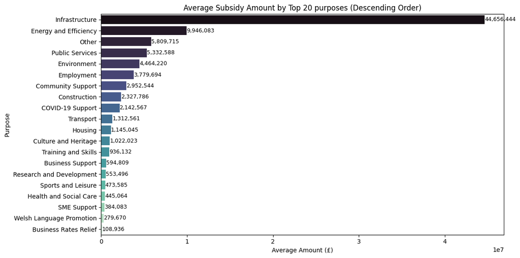

```python
purpose_stats = non_zero_amount.groupby('simplified_category')['amount_full'].agg(['mean', 'count'])


top_sectors = purpose_stats.sort_values(by='count', ascending=False).head(20)

top_sectors = top_sectors.sort_values(by='mean', ascending=False)



plt.figure(figsize=(12, 6))
ax = sns.barplot(x=top_sectors['mean'], y=top_sectors.index, palette='mako')

for i, (value, name) in enumerate(zip(top_sectors['mean'], top_sectors.index)):
    ax.text(value, i, f'{value:,.0f}', va='center', ha='left', fontsize=9)

plt.title('Average Subsidy Amount by Top 20 purposes (Descending Order)')
plt.xlabel('Average Amount (£)')
plt.ylabel('Purpose')
plt.tight_layout()
plt.show()
```

```python
non_zero_amount['recipient_size'].unique()
```

```
array(['SME', 'Large', 'Not specified', 'Large (250 or more employees)',
       'Small (between 10 and 49 employees)',
       'Medium (between 50 and 249 employees)',
       'Micro (fewer than 10 employees)', 'Small', 'Medium',
       'Large (more than 250 employees)', 'Micro organisation \n',
       'Micro – 0-9 employees', 'Large – 250 or more employees',
       'Medium - 50-249 employees ', 'Small – 10-49 employees', 'Micro ',
       'not available', 'Small(between 10 and 49 employees)',
       'Medium organisation', 'Small organisation', 'medium', 'small',
       'Micro', 'Large organisation', 'Large (250 or more employees)\xa0',
       'Small (between 10-49 employees)', 'Unknown', 'Micro Enterprise ',
       'Small Enterprise ', 'Medium Enterprise ',
       'Large organisation (250 or more employees)', 'Micro organisation',
       'Micro/Small'], dtype=object)
```

For further analysis will need to group them together into just a few clean categories

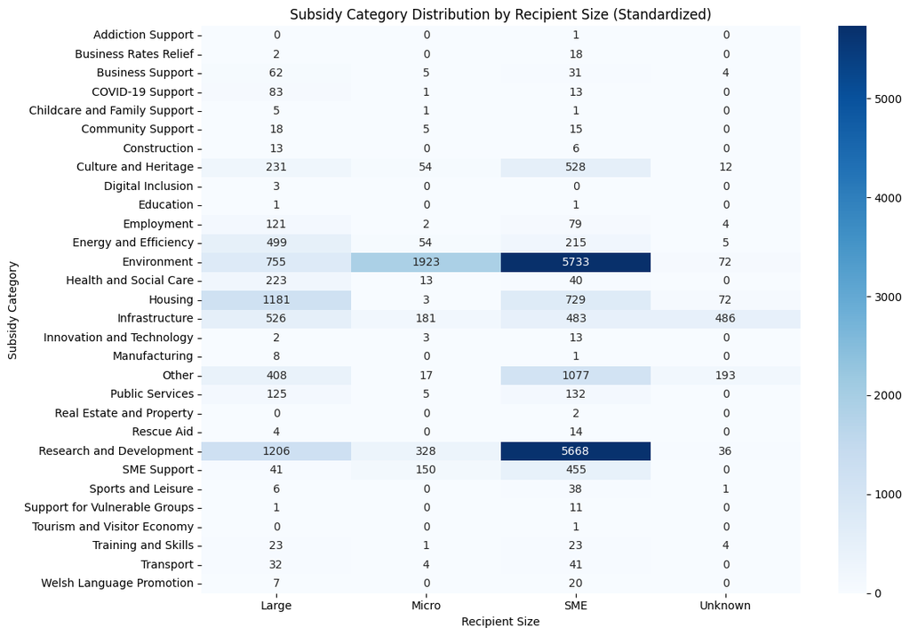

```python
# Define mapping for recipient_size to standardized categories
recipient_size_mapping = {
    'SME': 'SME',
    'Large': 'Large',
    'Not specified': 'Unknown',
    'Large (250 or more employees)': 'Large',
    'Small (between 10 and 49 employees)': 'SME',
    'Medium (between 50 and 249 employees)': 'SME',
    'Micro (fewer than 10 employees)': 'Micro',
    'Small': 'SME',
    'Medium': 'SME',
    'Large (more than 250 employees)': 'Large',
    'Micro organisation \n': 'Micro',
    'Micro – 0-9 employees': 'Micro',
    'Large – 250 or more employees': 'Large',
    'Medium - 50-249 employees ': 'SME',
    'Small – 10-49 employees': 'SME',
    'Micro ': 'Micro',
    'not available': 'Unknown',
    'Small(between 10 and 49 employees)': 'SME',
    'Medium organisation': 'SME',
    'Small organisation': 'SME',
    'medium': 'SME',
    'small': 'SME',
    'Micro': 'Micro',
    'Large organisation': 'Large',
    'Large (250 or more employees)\xa0': 'Large',
    'Small (between 10-49 employees)': 'SME',
    'Unknown': 'Unknown',
    'Micro Enterprise ': 'Micro',
    'Small Enterprise ': 'SME',
    'Medium Enterprise ': 'SME',
    'Large organisation (250 or more employees)': 'Large',
    'Micro organisation': 'Micro',
    'Micro/Small': 'Micro'
}

non_zero_amount['recipient_size_cleaned'] = non_zero_amount['recipient_size'].map(recipient_size_mapping).fillna('Unknown')

df_filtered = non_zero_amount.dropna(subset=['simplified_category', 'recipient_size_cleaned'])

pivot_table = df_filtered.pivot_table(
    index='simplified_category',
    columns='recipient_size_cleaned',
    aggfunc='size',
    fill_value=0
)

plt.figure(figsize=(12, 8))
sns.heatmap(pivot_table, annot=True, fmt='d', cmap='Blues')
plt.title('Subsidy Category Distribution by Recipient Size (Standardized)')
plt.xlabel('Recipient Size')
plt.ylabel('Subsidy Category')
plt.tight_layout()
plt.show()
```

- SME make up the overwhelming majority when summing up
- Notebly in environment related subsidies and R&D

```python
non_zero_amount['subsidy_form'].unique()
```

```
array(['Direct Grant', 'Other - Contract',
       'Other - To provide discounts on air fares for residents of remote regions to promote social cohesion.',
       'Other - Lending Capital and Grant', 'Other - Recoupable Grant',
       'Provision of goods or services below market prices', 'Loan',
       'Other - Business Rates Relief',
       'Other - Equity and Shareholder Loans',
       'Other - Development Investment repayable through a revenue sharing agreement',
       'Other - Deferred Interest Bearing Shares and Grant',
       'Other - Time limited revenue support',
       'Other - Business Rate Relief',
       'Other - Other - variable premium (payment of difference between market price of electricity and secured strike price)',
       'Other - Direct Grant plus Framework Support',
       'Other - Reimbursement of discount given to scheme members.',
       '1. Direct Grant', 'Direct Grant\n',
       'Other - Secondary Class 1 National Insurance contributions relief',
       'Other - Retail, Hospitality and Leisure 2024/25', 'Equity',
       'Other - Rate Relief',
       'Other - Payments on the generation and export of renewable electricity over 20 years. These payments are currently included as an estimate',
       'direct grant', 'Other - Community Infrastructure Levy Relief',
       'Other - Grant Award',
       'Other - 2023/24 Retail, Hospitality and Leisure Business Rates Relief Scheme',
       'Other - COVID-19 Additional Relief Fund (CARF)',
       'Other - 2023/24 Retail, Hospitality and Leisure Scheme',
       'Other - Support Payment', 'Other - Competed grant',
       'Other - Transfer of facility under a restricted lease',
       'Other - Grant and equity', 'Guarantee',
       'Other - Adjustment to Contract for Difference',
       'Other - Lease of 34 Hydrogen Buses under market value',
       'Other - Increased payment for care services under a pilot scheme',
       'Other - Funding was made available from DCMS to Network Rail under a 40-year royalty financing arrangement',
       'Other - Grant',
       'Other - Financial protection against insurance policy taken out by event organiser',
       'Other - Reimbursement of discount given to scheme members',
       'Other - A combination of direct grant and growth accelerator mechanism',
       'Other - Equity, loan and guarantee',
       'Other - GM Housing Investment Loans Fund - up to £9,300,000. Brownfield Housing Fund - £3,000,000',
       'Other - Housing Infrastructure Fund – Marginal Viability Fund £3,800,000 and Patient Equity £9,300,000',
       'Other - -'], dtype=object)
```

This could also be better formatted:

```python
def clean_subsidy_form(value):
    if pd.isna(value):
        return 'Other'
    val = value.strip().lower()

    if 'grant' in val:
        return 'Grant'
    elif 'loan' in val:
        return 'Loan'
    elif 'equity' in val:
        return 'Equity'
    elif 'guarantee' in val:
        return 'Guarantee'
    elif 'rate relief' in val or 'business rates relief' in val:
        return 'Rate Relief'
    elif 'contract' in val:
        return 'Contract'
    elif 'goods or services' in val or 'discount' in val or 'below market' in val:
        return 'Goods/Services Discount'
    else:
        return 'Other'

non_zero_amount['subsidy_form_cleaned'] = non_zero_amount['subsidy_form'].apply(clean_subsidy_form)

print(non_zero_amount['subsidy_form_cleaned'].value_counts())
```

```
subsidy_form_cleaned
Grant                      21593
Other                       2096
Goods/Services Discount      318
Guarantee                    305
Loan                         214
Contract                      49
Rate Relief                   32
Equity                         7
Name: count, dtype: int64
```

```python
streamlined_schemes = non_zero_amount[non_zero_amount['subsidy_num'].isin(['SC10780', 'SC10781', 'SC10782'])]
```

```python
streamlined_schemes['scheme_name'].unique()
```

```
array(['Energy Usage Streamlined Subsidy Scheme',
       'Research, Development and Innovation Streamlined Subsidy Scheme',
       'Local Growth Streamlined Subsidy Scheme'], dtype=object)
```

```python
# Group by quarter and category, summing the subsidy amounts
streamlined_quarterly = streamlined_schemes.groupby(['year_month_award', 'subsidy_num'])['amount_full'].sum().reset_index()

# Pivot for plotting
streamlined_pivot = streamlined_quarterly.pivot(index='year_month_award', columns='subsidy_num', values='amount_full').fillna(0)
```

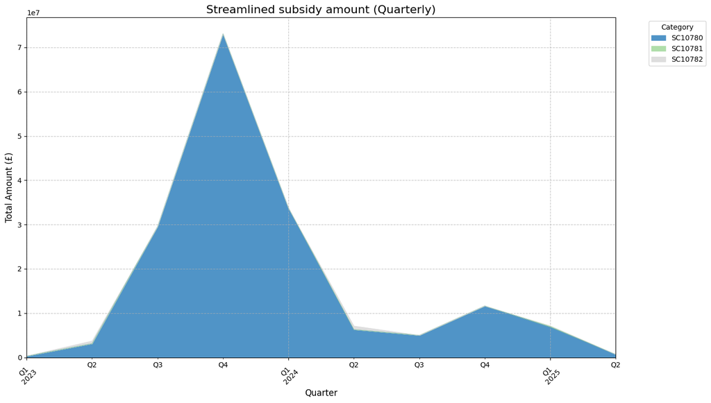

```python
plt.figure(figsize=(14, 8))

streamlined_pivot.plot(
    kind='area',
    stacked=True,
    figsize=(14, 8),
    colormap='tab20c',
    alpha=0.85,
    linewidth=0.5
)

plt.title('Streamlined subsidy amount (Quarterly)', fontsize=16)
plt.xlabel('Quarter', fontsize=12)
plt.ylabel('Total Amount (£)', fontsize=12)
plt.xticks(rotation=45)
plt.grid(True, linestyle='--', alpha=0.7)
plt.legend(title='Category', bbox_to_anchor=(1.05, 1), loc='upper left')
plt.tight_layout()
plt.show()
```